# Proyecto diplomado exploración de datos

Jonathan Maureira

2023-08-06

# Titulo: Cataratas e impacto productivo en Salmo Salar

Autor: Jonathan Maureira

Médico Veterinaria

Jmaureira.mv@gmail.com

## Objetivos:

Descripción de la problemática:

Cualquier alteración física en la población de salmónidos de producción, representan un desafío significativo en los resultados productivos.

Las cataratas se definen como la alteración ocular que resulta en la opacidad del cristalino. Esta opacidad disminuye la cantidad de luz que ingresa al ojo por ende disminuye la capacidad de visión en los peces.

Se plantea la hipótesis de que una mayor severidad de cataratas en los peces tendrá un impacto relevante en la producción, ya que los peces afectados tendrían una menor capacidad de competitividad por el alimento, con respecto a los peces sanos. En este estudio, se examinará el Índice de Desarrollo de Cataratas (IDC), cuya puntuación varía entre 0 y 24. Para calcular este índice, se combinan dos subíndices: uno que evalúa la extensión de la catarata en una escala de 0 a 4 y otro que mide la densidad de la catarata en una escala de 1 a 3. Primero, se suman los subíndices de ambos ojos y luego se promedian los puntos de densidad de cada ojo del pez y por ultimos se multiplican los subíndicen de extencion x el subíndice de densidad.

Con este enfoque, se pretende evaluar el nivel de desarrollo de cataratas en los peces, clasificarlos según su severidad y relacionarlo con el Indice de Condicion (K) según la formula de Fulton (K)=(W/L^3)*100, donde W= peso del pez en gramos y L= longitud la cual es elevada al cubo. Esto permitirá comprender mejor el impacto de las cataratas en la población de peces y su producción.

**Score de extension de cataratas y score de densidad de cataratas**

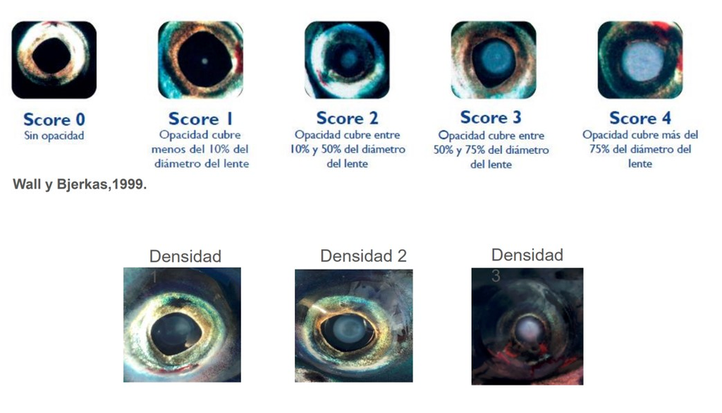

**Cita Bibliografica:** Wall T., Bjerkås E. 1999. A simplified method of scoring cataracts in fish. Bull. Eur. Pathol. 19(4): 1 https://eafp.org/download/1999-Volume19/Issue%204/19%204%20162-165.pdf  
**Tabla resumen de Categoria cataratas**

[output not shown]

**Base de datos**

```
##     Centro              Fecha                            Jaula
##  Length:3206        Min.   :2022-10-26 00:00:00.00   Min.   :201.0
##  Class :character   1st Qu.:2022-12-27 00:00:00.00   1st Qu.:202.0
##  Mode  :character   Median :2023-01-24 00:00:00.00   Median :206.0
##                     Mean   :2023-01-20 12:06:44.24   Mean   :205.8
##                     3rd Qu.:2023-02-15 00:00:00.00   3rd Qu.:208.0
##                     Max.   :2023-04-18 00:00:00.00   Max.   :212.0
##
##    Numero pez          Peso         Longitud           K
##  Min.   :  1.00   Min.   :   0   Min.   : 0.00   Min.   :0.000
##  1st Qu.: 25.00   1st Qu.:1350   1st Qu.:45.00   1st Qu.:1.343
##  Median : 49.00   Median :1750   Median :49.00   Median :1.438
##  Mean   : 49.78   Mean   :1747   Mean   :44.95   Mean   :1.439
##  3rd Qu.: 75.00   3rd Qu.:2288   3rd Qu.:54.00   3rd Qu.:1.536
##  Max.   :107.00   Max.   :4400   Max.   :70.00   Max.   :2.713
##                   NA's   :2368   NA's   :2366    NA's   :2467
##       IDC
##  Min.   : 0.000
##  1st Qu.: 0.000
##  Median : 2.000
##  Mean   : 5.223
##  3rd Qu.:10.000
##  Max.   :24.000
##  NA's   :3
```

```
## [1] 3206    8
```

**Nota:** En este resumen de la base de datos de cataratas, se presenta el universo completo de datos sin aplicar ningún filtro. Se han detectado 3206 observaciones que abarcan 8 variables. Se ha realizado un análisis para verificar la presencia de datos duplicados, y no se han encontrado registros. Además, se han eliminado los datos faltantes utilizando la función na.omit. Además, se ha llevado a cabo una filtración de datos no lógicos mediante la función filter. En particular, se han excluido los valores extremos de la variable K (Índice de Condición), es decir, aquellos que superan el valor de 2,5 de K.

```
##           Centro        Fecha            Jaula       Numero pez
##  Loncochalgua:730   Min.   :2023-01-18   201:143   Min.   : 1.00
##                     1st Qu.:2023-01-18   202:195   1st Qu.:13.00
##                     Median :2023-02-15   204: 50   Median :26.00
##                     Mean   :2023-02-17   207:145   Mean   :25.62
##                     3rd Qu.:2023-03-21   208: 49   3rd Qu.:38.00
##                     Max.   :2023-04-18   212:148   Max.   :50.00
##
##       Peso         Longitud           K               IDC        cat_catarata
##  Min.   : 550   Min.   :36.00   Min.   :0.7823   0      :209   normal  :209
##  1st Qu.:1500   1st Qu.:47.00   1st Qu.:1.3434   12     :116   leve    :237
##  Median :1850   Median :50.50   Median :1.4383   8      :107   moderado:221
##  Mean   :1983   Mean   :51.09   Mean   :1.4439   18     : 59   severo  : 63
##  3rd Qu.:2350   3rd Qu.:55.00   3rd Qu.:1.5364   6      : 57
##  Max.   :4400   Max.   :70.00   Max.   :2.1875   12.5   : 42
##                                                  (Other):140
```

```
## [1] 730   9
```

**Nota:** En este resumen de la base de datos de cataratas, se aprecia la disminucion de la observaciones luego de aplicar los filtros, quedando 730 observaciones con 9 variables.Se ha incorporado la variable cat_catarata (categoría de cataratas). Utilizando la función case_when, se asignaron categorías a los puntajes del Índice de Desarrollo de Cataratas, y se les proporcionará un orden lógico de caracterización de menos a más, reflejando el grado de severidad, gracias al uso de la función levels.

## Analisis exploratorio

|  | 201 | 202 | 204 | 207 | 208 | 212 |
| --- | --- | --- | --- | --- | --- | --- |
| normal | 76 | 51 | 8 | 23 | 12 | 39 |
| leve | 33 | 70 | 20 | 62 | 22 | 30 |
| moderado | 30 | 55 | 16 | 52 | 11 | 57 |
| severo | 4 | 19 | 6 | 8 | 4 | 22 |

**Nota** Se puede apreciar una falta de balance en los datos, debido a que la cantidad de individuos entre cada jaula varía significativamente y además, existe una disparidad en la cantidad de observaciones por cada categoría.

## Histogramas

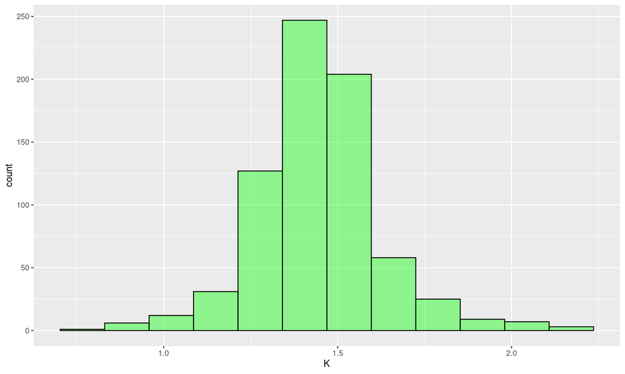

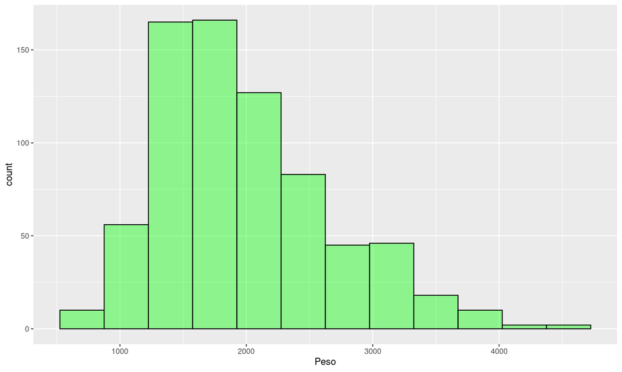

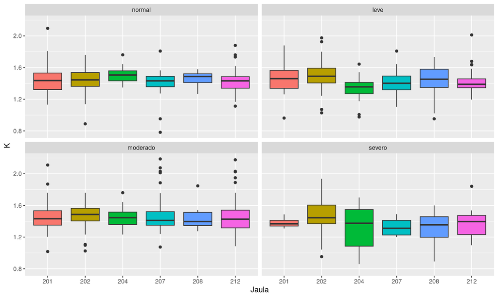

| categoria catarata | Frecuencia |
| --- | --- |
| normal | 209 |
| leve | 237 |
| moderado | 221 |
| severo | 63 |

| Jaula | Frecuencia |
| --- | --- |
| 201 | 143 |
| 202 | 195 |
| 204 | 50 |
| 207 | 145 |
| 208 | 49 |
| 212 | 148 |

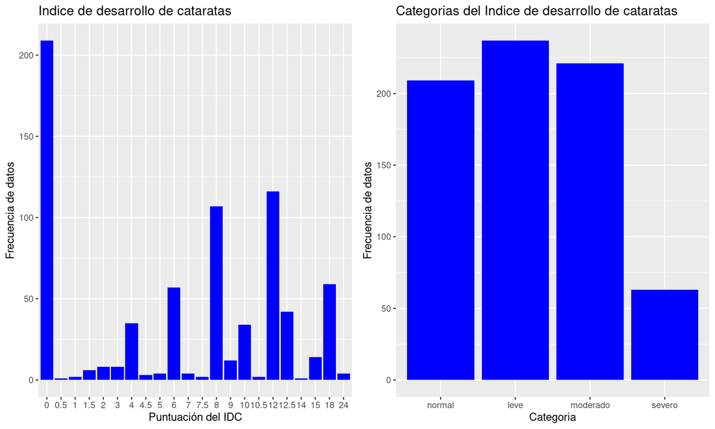

## Analisis a traves de Boxplot

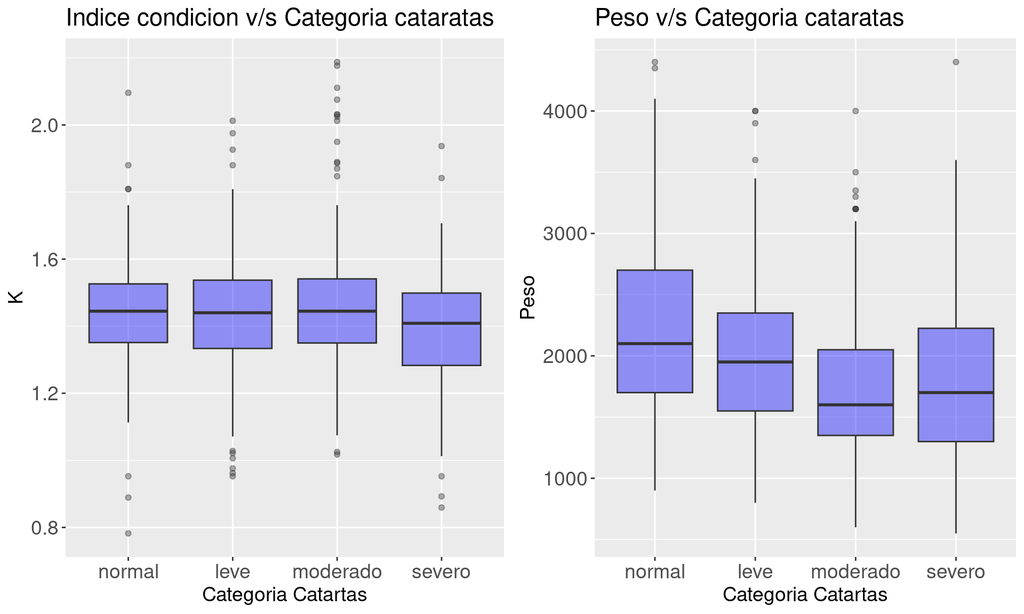

**Nota** La variable peso no seria la mas indicada por que la toma de muestras de datos se tomaron en distintas fechas del ciclo productivo. La variable de K es la mas indicada.

[figure not shown]

**Nota:** Variable corresponde a una variable cuantitativa discreta.

| cat_catarata | n | promedio | desv | mediana | valor_maximo | valor_minimo |
| --- | --- | --- | --- | --- | --- | --- |
| normal | 209 | 1.44 | 0.16 | 1.44 | 2.10 | 0.78 |
| leve | 237 | 1.44 | 0.17 | 1.44 | 2.01 | 0.95 |
| moderado | 221 | 1.47 | 0.20 | 1.44 | 2.19 | 1.02 |
| severo | 63 | 1.39 | 0.21 | 1.41 | 1.94 | 0.86 |

| Jaula | n | promedio | desv | mediana | valor_maximo | valor_minimo |
| --- | --- | --- | --- | --- | --- | --- |
| 201 | 143 | 1.45 | 0.17 | 1.44 | 2.11 | 0.96 |
| 202 | 195 | 1.47 | 0.17 | 1.48 | 1.98 | 0.89 |
| 204 | 50 | 1.40 | 0.19 | 1.41 | 1.76 | 0.86 |
| 207 | 145 | 1.43 | 0.18 | 1.41 | 2.19 | 0.78 |
| 208 | 49 | 1.43 | 0.18 | 1.44 | 1.85 | 0.89 |
| 212 | 148 | 1.44 | 0.19 | 1.42 | 2.18 | 1.09 |

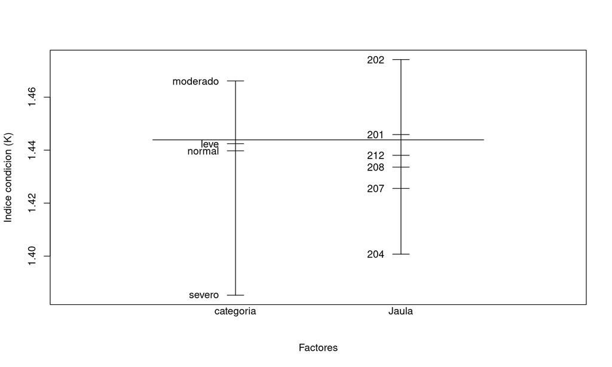

## Analisis de correlacion de Spearman’s

Hipótesis nula (H0): No existe correlacion entrel el indice de condición (K) de los peces con respecto a la severidad del indice de desarrollo de las cataratas (IDC).

Hipótesis alternativa (H1): Existe correlacion entrel el indice de condición (K) de los peces con respecto a la severidad del indice de desarrollo de las cataratas (IDC).

```
##
##  Spearman's rank correlation rho
##
## data:  BDC_Spearman$IDC and BDC_Spearman$K
## S = 66822558, p-value = 0.4085
## alternative hypothesis: true rho is not equal to 0
## sample estimates:
##         rho
## -0.03063902
```

**Nota:**Se realiza el analisis de correlacion de spearman ya que las variables no son parametricas. Este analisis realiza la correlacion a traves del ranking de los resultados.

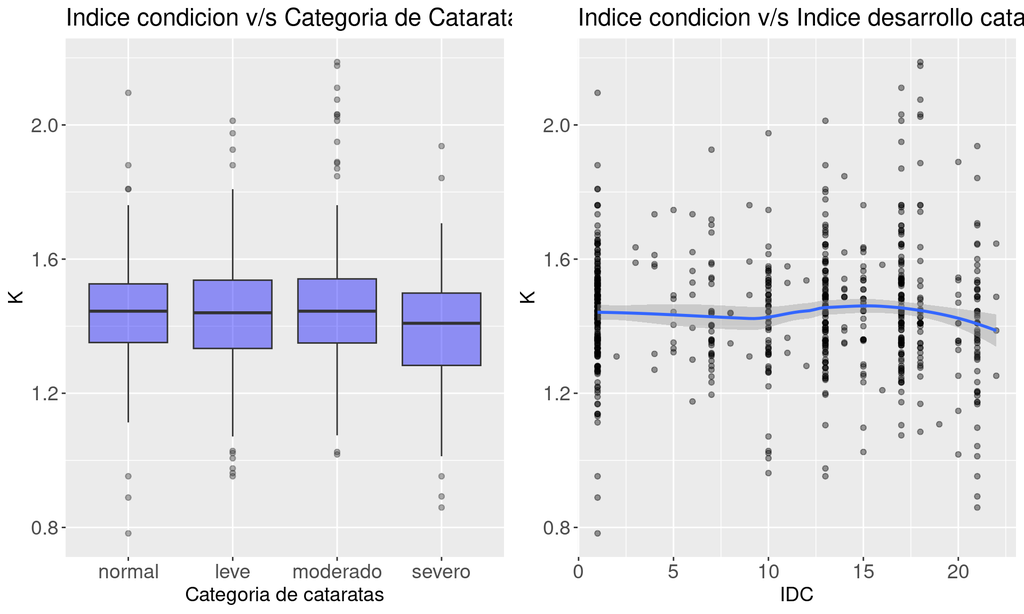

## Resultados:

Según los resultados del análisis de conexiones de Spearman, se ha aceptado la hipótesis nula debido a la falta de evidencia para rechazarla. El coeficiente de concreciones (rho) calculado es de -0,03063902, lo que no es significativamente diferente de cero, como se refleja en el valor de probabilidad (p-value) de 0,4085, el cual es mayor a 0,05.

Estos resultados sugieren que no existe una relación significativa entre el Índice de Condición (K) y la severidad de las cataratas en esta base de datos.

Aunque en el gráfico se aprecia una leve tendencia de conexión negativa, es probable que esta tendencia no sea significativa debido a la baja severidad de las cataratas.

En resumen, de acuerdo con el análisis estadístico y la visualización gráfica, no se ha encontrado una correlación significativa entre el Índice de Condición y la severidad de las cataratas en la muestra analizada.

## Analisis de correlacion de Kruskal-Wallis

Hipótesis nula (H0): No hay diferencias significativas en las medianas del índice de condición K entre las categorías de cataratas.

Hipótesis alternativa (H1): Existen diferencias significativas en las medianas del índice de condición K entre las categorías de cataratas.

```
##
##  Kruskal-Wallis rank sum test
##
## data:  K by cat_catarata
## Kruskal-Wallis chi-squared = 5.5624, df = 3, p-value = 0.135
```

## Resultados:

Dado que el valor de probabilidad (p = 0.135) es mayor que el nivel de significancia utilizado P = 0.05, no hay evidencia para rechazar la hipótesis nula.

No se encontraron diferencias significativas en las medianas del índice de condición K y entre las categorías de cataratas.

Según la prueba de Kruskal-Wallis, no podemos concluir que la categoría de cataratas tenga un efecto significativo sobre el índice de condición K.